# Text Prediction

```r
library(stringr) # wordcount
library(tm)
library(SnowballC)
library(RWeka) # n-grams
library(wordcloud2) # wordcloud
library(wordcloud)
library(knitr)
library(tidytext)
library(dplyr)
library(data.table)
library(wordcloud)
library(RColorBrewer)
library(tidyr)
library(igraph)
library(ggraph)
```

# Principles

1. “Text mining” : download and clean the dataset for analysis.
   - predictive machine isn’t text mining for ordering or analysis
   - question for stemming and remove stopwords, because people write them so they need predictive dictionary
2. Exploratory Analysis :
   - understand the distribution and the relationship between the words, tokens and phrases.
   - understand basic relationship in the data
   - prepare to build the first linguistic model

# Text Mining

## Theory

- initial text
- preprocessing - cleaning corpus
  - all to lower
  - remove punctuation, numbers, url,…
  - remove stopwords
  - remove whitespaces
  - remove word less than 2 char
  - Stemming / Lemming
- Tokenization (1 and n-grams)
- keywords lexical

## Decision to make

1. sample datasets ?
2. Separate datasets ?
   - twit are short message with lots of typo, and news / blogs are more developed text
   - train model on different purposes, for different users.
3. Remove stopwords ?
   - Stopwords useful for prediction typing algo
   - Stopwords to remove for sorting algo
4. Stemming or not ?
   - Good to unite declinaison of words, and remove some typos

# Packages

## Create corpus

```r
library(tm)
twit <- readLines("../text/en_US.twitter.txt", skipNul=TRUE)
```

Quick exploratory :

```r
# function to view some stats
# str_count(texte, '\\w+') to count words in texte
overview <- function(texte) {
    data.frame(total.Lines=length(texte), total.words=sum(str_count(texte,'\\w+')), mean.word.by.line=mean(str_count(texte,'\\w+')), sd.of.mean=sd(str_count(texte,'\\w+')), max.word.by.line=max(str_count(texte,'\\w+')))
}
dataSum <- overview(twit)

# view results
library(knitr)
knitr::kable(dataSum)
```

| total.Lines | total.words | mean.word.by.line | sd.of.mean | max.word.by.line |
| --- | --- | --- | --- | --- |
| 2360148 | 31003544 | 13.13627 | 7.124297 | 47 |

```r
twit[1]
```

```
[1] "How are you? Btw thanks for the RT. You gonna be in DC anytime soon? Love to see you. Been way, way too long."
```

Searching some words (for quizz, but can be useful in other cases). Use *grep()* function :

```r
length(twit)
```

```
[1] 2360148
```

```r
nbLinesLove <- length(grep("love", twit))
nbLinesHate <- length(grep("hate", twit))
nbLinesLove / nbLinesHate
```

```
[1] 4.108592
```

```r
twit[grep("biostats", twit)]
```

```
[1] "i know how you feel.. i have biostats on tuesday and i have yet to study =/"
```

```r
grep("A computer once beat me at chess, but it was no match for me at kickboxing", twit)
```

```
[1]  519059  835824 2283423
```

## tm package

### Sources

- [data.bzh](http://data-bzh.fr/?s=text+mining)
- [whatsupdata.fr](http://whatsupdata.fr/content/le-text-mining-et-la-d%C3%A9couverte-des-principales-%C2%AB-th%C3%A9matiques-%C2%BB-d%E2%80%99un-corpus-de-documents)
- [gentle introduction to text mining using R](https://eight2late.wordpress.com/2015/05/27/a-gentle-introduction-to-text-mining-using-r/)
- [gentle introduction to topic modeling using R](https://eight2late.wordpress.com/?s=topic+model)
- [R code : reading, preprocessing and counting](http://www.katrinerk.com/courses/words-in-a-haystack-an-introductory-statistics-course/schedule-words-in-a-haystack/r-code-the-text-mining-package)

### Pre-processing

Select random sample for testing process and functions :

```r
library(tm)
set.seed(2704)
twitTest <- sample(twit, 2000, replace=F)
```

Unecessary items in text mining are : punctuation, numbers, url, etc.  
To have the transformations possible with tm package :

```r
getTransformations()
```

```
[1] "removeNumbers"     "removePunctuation" "removeWords"
[4] "stemDocument"      "stripWhitespace"
```

```r
cleanCorpus <- function(textFile, lang="english", stopwords=FALSE, stemming=FALSE) {
    # take a text file or a text variable, and a language, and return a clean and stemmed corpus
    library(tm)
    library(SnowballC)
    if(length(textFile)==1) {
        # textFile is a path to file must be read
        texte <- readLines(textFile, skipNul=TRUE)
    } else {
        # textFile is a variable already read
        texte <- textFile
    }
    # create corpus with file
    corpus <- VCorpus(VectorSource(texte))
    # clean and stem corpus
    corpus <- tm_map(corpus, content_transformer(tolower))
    corpus <- tm_map(corpus, removePunctuation)
    corpus <- tm_map(corpus, removeNumbers)
    if(stopwords==TRUE){
        corpus <- tm_map(corpus, removeWords, stopwords(lang))
    }
    if(stemming==TRUE){
        corpus <- tm_map(corpus, stemDocument, language=lang)
    }
    corpus <- tm_map(corpus, stripWhitespace)
    corpus
}

twitClean <- cleanCorpus(twitTest, stopwords=TRUE, stemming=TRUE)
print(object.size(twitClean), units="auto", quote=FALSE)
```

```
4.4 Mb
```

Possibility to remove specific words :

```r
twitClean <- tm_map(twitClean, removeWords, c("one", "two"))
```

Lemming - more accurate ?

- class words on lemm (run ran running -> run), based on the signification
- use packages [TreeTagger](http://www.cis.uni-muenchen.de/~schmid/tools/TreeTagger/#Linux) and koRpus.
- don’t work, don’t know why…

To illustrate before and after the processing :

```r
result <- data.frame(before=twitTest[[27]], after=twitClean[[27]]$content)
knitr::kable(result, row.names=F)
```

| before | after |
| --- | --- |
| Had a huge crowd at our Ambassador info session last night. Missed it? Join us tonight 6:30-7:30 in Butler Boardroom. | huge crowd ambassador info session last night miss join us tonight butler boardroom |

### Exploratory Analysis

Questions to consider : - what are the distribution of words frequencies ? + analysis with and without stopwords ? - what are the frequencies of 2-grams and 3-grams ? - How many unique words in a frequency sorted dictionary to cover 50% of all words instance ? 90% ? - how to increase the coverage ? + analysis without stemming + try with stemming in order to increase coverage - how evaluate how many words from foreign languages ?

#### Distribution of frequencies of words

Term Document Matrix is a table containing the frequency of words.

```r
tdm <- TermDocumentMatrix(twitClean)
tdm
```

```
<<TermDocumentMatrix (terms: 4377, documents: 2000)>>
Non-/sparse entries: 13645/8740355
Sparsity           : 100%
Maximal term length: 33
Weighting          : term frequency (tf)
```

```r
cleanDF <- function(tdm) {
    # take a tdm and return a dataframe with words/ngrams and ordered frequencies
    m <- as.matrix(tdm)
    v <- sort(rowSums(m), decreasing=T)
    d <- data.frame(word=names(v), freq=v, percent=v/sum(v)*100,
                    cumulative_percent=cumsum(v/sum(v)*100))
    d
}

d <- cleanDF(tdm)
knitr::kable(head(d), row.names=F)
```

| word | freq | percent | cumulative_percent |
| --- | --- | --- | --- |
| just | 132 | 0.9421842 | 0.9421842 |
| get | 130 | 0.9279086 | 1.8700928 |
| like | 113 | 0.8065667 | 2.6766595 |
| love | 98 | 0.6995004 | 3.3761599 |
| thank | 94 | 0.6709493 | 4.0471092 |
| day | 93 | 0.6638116 | 4.7109208 |

```r
knitr::kable(tail(d), row.names=F)
```

| word | freq | percent | cumulative_percent |
| --- | --- | --- | --- |
| zero | 1 | 0.0071378 | 99.96431 |
| zeta | 1 | 0.0071378 | 99.97145 |
| ziggan | 1 | 0.0071378 | 99.97859 |
| zodin | 1 | 0.0071378 | 99.98572 |
| zooey | 1 | 0.0071378 | 99.99286 |
| zyzzva | 1 | 0.0071378 | 100.00000 |

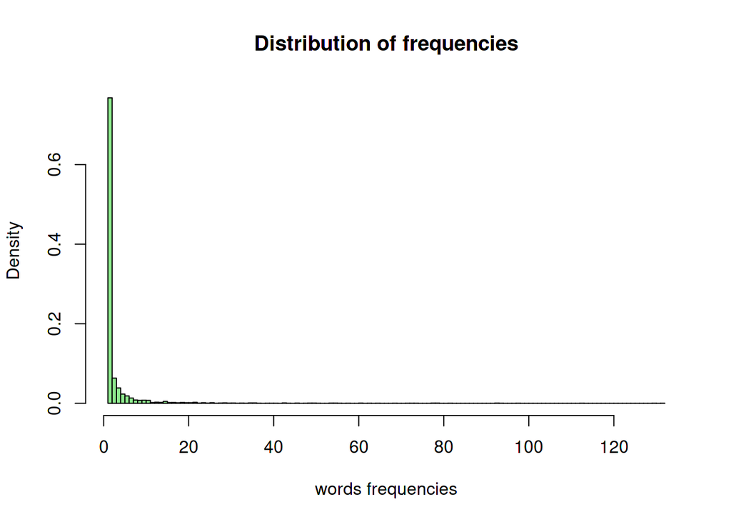

```r
breakNb <- 1:d[1,]$freq
hist(d$freq, breaks=breakNb, freq=FALSE, col="lightgreen", border="black",
     main="Distribution of frequencies", xlab="words frequencies")
```

#### Minimum unique words to cover distribution

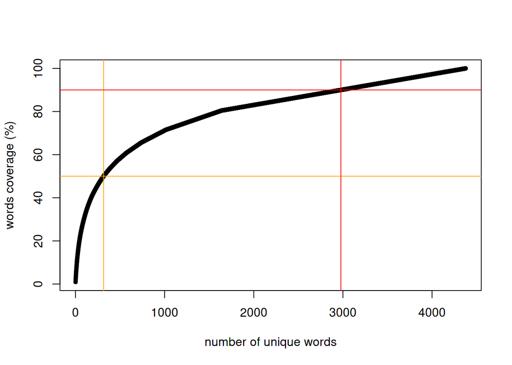

```r
# could do a function to choose the coverage value.
plot(d$cumulative_percent, pch=20, xlab="number of unique words", ylab="words coverage (%)")
abline(h=50, col="orange")
abline(v=which(d$cumulative_percent > 50)[1], col="orange")
abline(h=90, col="red")
abline(v=which(d$cumulative_percent > 90)[1], col="red")
```

```r
index50 <- which(d$cumulative_percent > 50)[1]
index90 <- which(d$cumulative_percent > 90)[1]

coverWords <- data.frame(percent50=index50, percent90=index90)
row.names(coverWords) <- "number of unique words"
knitr::kable(coverWords)
```

|  | percent50 | percent90 |
| --- | --- | --- |
| number of unique words | 316 | 2977 |

#### Plot most frequents words

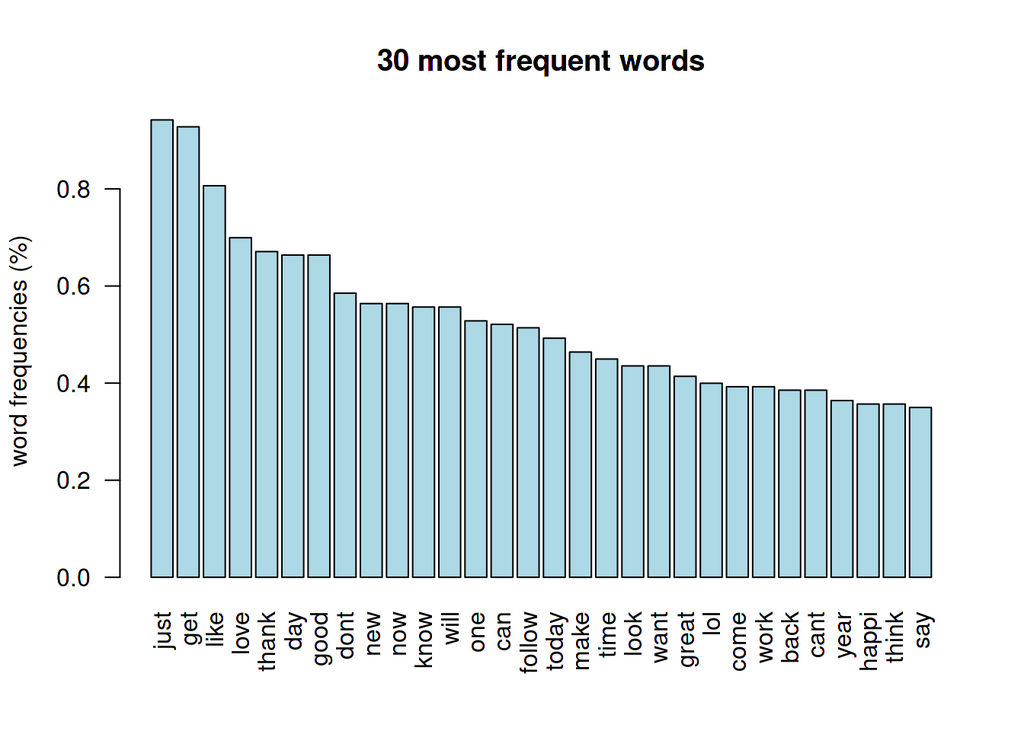

```r
barplot(d[1:30,]$percent, names.arg=d[1:30,]$word, col="lightblue", las=2,
        main="30 most frequent words", ylab="word frequencies (%)")
```

#### Generate Wordcloud

Visual funny representation, use the *wordcloud2()* function of the wordcloud2 package.

```r
library(wordcloud2)
d <- cleanDF(tdm)
wordcloud2(d, size=0.6)
```

[interactive chart not shown]

### 2 and 3-grams

Use the *weka()* function of the RWeka package with tm().

```r
tdmNgram <- function(corpus, nb=2){
    # take a corpus, min and max length of ngram, and return a tdm of ngrams
    library(RWeka)
    library(tm)
    options(mc.cores=1)
    # http://stackoverflow.com/questions/17703553/bigrams-instead-of-single-words-in-termdocument-matrix-using-r-and-rweka/20251039#20251039
    ngramControl <- function(x) {
        RWeka::NGramTokenizer(x, Weka_control(min=nb, max=nb))
    }
    tdm <- TermDocumentMatrix(corpus, control=list(tokenize=ngramControl))
    tdm
}

twoGram <- tdmNgram(twitClean, 2)
knitr::kable(head(cleanDF(twoGram)), row.names=F)
```

| word | freq | percent | cumulative_percent |
| --- | --- | --- | --- |
| right now | 21 | 0.1625261 | 0.1625261 |
| last night | 13 | 0.1006114 | 0.2631375 |
| look forward | 13 | 0.1006114 | 0.3637489 |
| im go | 12 | 0.0928721 | 0.4566210 |
| cant wait | 11 | 0.0851327 | 0.5417537 |
| good morn | 9 | 0.0696541 | 0.6114078 |

```r
threeGram <- tdmNgram(twitClean, 3)
knitr::kable(head(cleanDF(threeGram)), row.names=F)
```

| word | freq | percent | cumulative_percent |
| --- | --- | --- | --- |
| let us know | 5 | 0.0455539 | 0.0455539 |
| cant wait til | 3 | 0.0273324 | 0.0728863 |
| help spread word | 3 | 0.0273324 | 0.1002187 |
| just got done | 3 | 0.0273324 | 0.1275510 |
| buy new macbook | 2 | 0.0182216 | 0.1457726 |
| can pleas follow | 2 | 0.0182216 | 0.1639942 |

## tidytext package

Source : [tidytextmining.com](http://tidytextmining.com/)

Good to use method like dplyr, very easy to use with pipe. Can be directly piped to ggplot2.  
Datasets must be a dataframe to use the `unnest_tokens()` function.  
Has to write number of lines in a column, then the text dataset in an other, unless error with ‘indice hors limite’.

### General use

```r
library(tidytext)
library(dplyr)
library(data.table)
twitTest <- sample(twit, 20000, replace=F)
head(twitTest)
```

```
[1] "I say go for it as long as you aren't attached to playlists. Lots of standard playlist management features missing from Rdio."
[2] "Championship Sunday is here! Let's go Big Blue 💙🏈💙🏈💙"
[3] "you are welcome, btw nice tee's dig your style."
[4] "same I have no life. :("
[5] "\"Every death has a two part chapter I do what I do, cause I do what I have ta.\" J-Funk. They call me Angel."
[6] "Thanks for the fab review, Kari!"
```

```r
dfTwit <- data.table(line=1:20000, text=twitTest)
str(dfTwit)
```

```
Classes 'data.table' and 'data.frame':  20000 obs. of  2 variables:
 $ line: int  1 2 3 4 5 6 7 8 9 10 ...
 $ text: chr  "I say go for it as long as you aren't attached to playlists. Lots of standard playlist management features missing from Rdio." "Championship Sunday is here! Let's go Big Blue 💙🏈💙🏈💙" "you are welcome, btw nice tee's dig your style." "same I have no life. :(" ...
 - attr(*, ".internal.selfref")=<externalptr>
```

```r
print(object.size(dfTwit), units="auto", quote=FALSE)
```

```
2.3 Mb
```

```r
tidyText <- dfTwit %>% unnest_tokens(word, text)
tidyText <- tidyText %>% filter(!grepl('[0-9]', word))

str(tidyText)
```

```
'data.frame':   249585 obs. of  2 variables:
 $ line: int  1 1 1 1 1 1 1 1 1 1 ...
 $ word: chr  "i" "say" "go" "for" ...
 - attr(*, ".internal.selfref")=<externalptr>
```

```r
head(tidyText)
```

```
  line word
1    1    i
2    1  say
3    1   go
4    1  for
5    1   it
6    1   as
```

```r
print(object.size(tidyText), units="auto", quote=FALSE)
```

```
2.7 Mb
```

Note that :

- punctuation has been removed
- unnest_tokens converts the token to lower case.
- numbers are removed with the `filter()` and `grepl()` functions, and a regexp.

Many options available to tweak default behaviour. Easy to use tiny method like dplyr, tidyr, ggplot2 and broom.

### Stopwords

Use `anti_join()` function with the stop_words data.

```r
data(stop_words)
stopText <- tidyText %>% anti_join(stop_words)
dim(stopText)
```

```
[1] 101041      2
```

```r
head(stopText)
```

```
   line        word
1 20000      assbag
2 19999 remembrance
3 19999     funeral
4 19999     freeman
5 19999      strand
6 19994       tacky
```

```r
print(object.size(stopText), units="auto", quote=FALSE)
```

```
1.5 Mb
```

### Most commun words

Use `count()` function.

```r
freqWord <- stopText %>% count(word, sort=T)
head(freqWord)
```

```
# A tibble: 6 × 2
    word     n
   <chr> <int>
1   love   887
2     rt   779
3    day   763
4   time   650
5    lol   563
6 people   414
```

Easy to plot with pipe and tidy dataset :

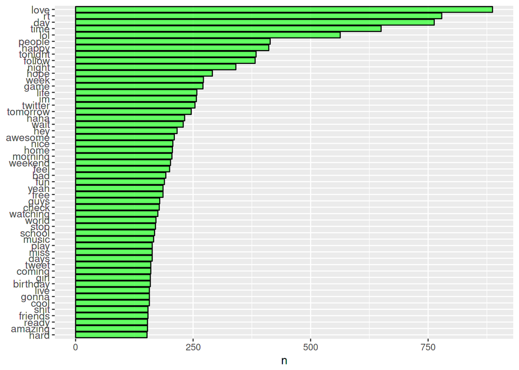

```r
library(ggplot2)
data(stop_words)
tidyText %>%
    anti_join(stop_words) %>%
    count(word, sort=TRUE) %>%
    filter(n>150) %>%
    mutate(word=reorder(word,n)) %>%
    ggplot(aes(word,n)) +
    geom_bar(stat="identity", fill="green", color="black", alpha=0.6) +
    xlab(NULL) +
    theme(axis.text.y = element_text(size=10)) +
    coord_flip()
```

```r
library(wordcloud)
library(RColorBrewer)
countTidyText <- tidyText %>% anti_join(stop_words) %>%
    count(word, sort=T)
countTidyText
```

```
# A tibble: 21,595 × 2
      word     n
     <chr> <int>
1     love   887
2       rt   779
3      day   763
4     time   650
5      lol   563
6   people   414
7    happy   411
8  tonight   384
9   follow   382
10   night   341
# ... with 21,585 more rows
```

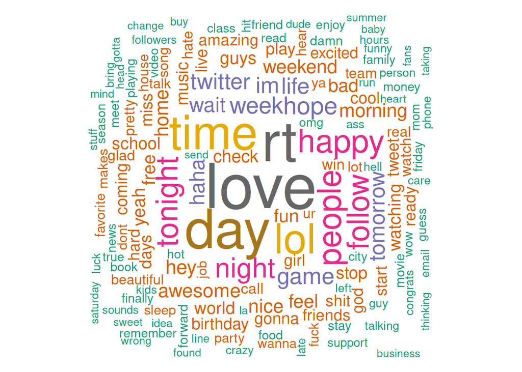

```r
# wordcloud(as.data.frame(countTidyText), size=0.6)
wordcloud(words=countTidyText$word, freq=countTidyText$n, max.words=150, random.order=F, rot.per=0.4, scale=c(5,0.5), colors=brewer.pal(8,"Dark2"))
```

### Relations between words

#### N-grams

N-grams con be created with the token option :

```r
bigrams <- dfTwit %>%
    unnest_tokens(bigram, text, token="ngrams", n=2)
bigrams <- bigrams %>% filter(!grepl('[0-9]', bigram))
str(bigrams)
```

```
Classes 'tbl_df', 'tbl' and 'data.frame':   226330 obs. of  2 variables:
 $ line  : int  1 1 1 1 1 1 1 1 1 1 ...
 $ bigram: chr  "i say" "say go" "go for" "for it" ...
```

```r
head(bigrams)
```

```
# A tibble: 6 × 2
   line  bigram
  <int>   <chr>
1     1   i say
2     1  say go
3     1  go for
4     1  for it
5     1   it as
6     1 as long
```

Now we can examine the most common bigrams :

```r
bigrams %>% count(bigram, sort=T)
```

```
# A tibble: 124,360 × 2
       bigram     n
        <chr> <int>
1      in the   650
2     for the   646
3      of the   467
4      on the   424
5  thanks for   397
6       to be   397
7      to the   379
8      at the   344
9   thank you   301
10   going to   295
# ... with 124,350 more rows
```

And the most common bigrams without stopwords : use the `separate()` function of the `tidyr` package, which split column into multiple based on a separator :

```r
library(tidyr)
separate_bigrams <- bigrams %>%
    separate(bigram, c("word1","word2"), sep=" ")
filtered_bigrams <- separate_bigrams %>%
    filter(!word1 %in% stop_words$word) %>%
    filter(!word2 %in% stop_words$word)
# new count
filtered_bigrams %>% count(word1, word2, sort=TRUE)
```

```
Source: local data frame [31,589 x 3]
Groups: word1 [11,801]

       word1    word2     n
       <chr>    <chr> <int>
1      happy birthday    92
2     social    media    28
3       stay    tuned    23
4   mother's      day    22
5         rt       rt    21
6  beautiful      day    18
7    mothers      day    18
8      happy   easter    16
9       game  tonight    15
10       god    bless    15
# ... with 31,579 more rows
```

Then `unite()` from the `tidyr` package to merge column and plot a wordcloud of most commons bigrams.

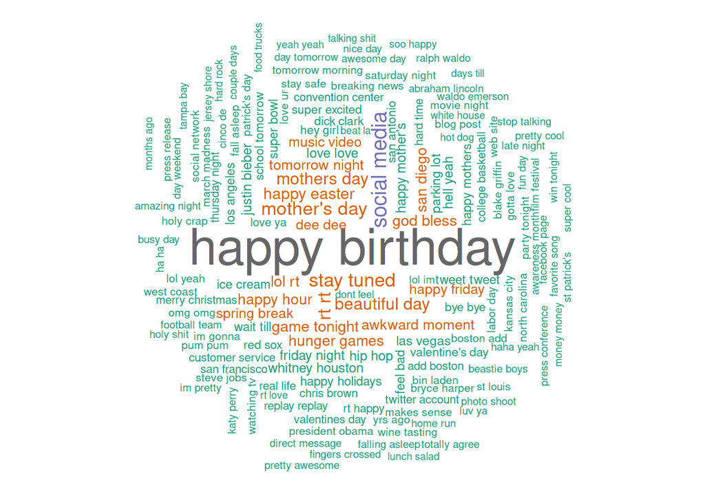

```r
united_bigrams <- filtered_bigrams %>%
    unite(bigram, word1, word2, sep=" ")
counted_bigrams <- united_bigrams %>%
    count(bigram, sort=TRUE)
wordcloud(words=counted_bigrams$bigram, freq=counted_bigrams$n, max.words=150, random.order=F, rot.per=0.35, scale=c(3,0.5), colors=brewer.pal(8,"Dark2"))
```

#### Network of bigrams

Network of bigrams can be drawn with `graph_from_data_frame()` function from the `igraph` package, and `ggraph()` from `ggraph` package.

```r
library(igraph)
filtered_bigrams
```

```
# A tibble: 34,468 × 3
    line        word1      word2
   <int>        <chr>      <chr>
1      1    playlists       lots
2      1     standard   playlist
3      1     playlist management
4      1   management   features
5      1     features    missing
6      2 championship     sunday
7      3          btw       nice
8      3         nice      tee's
9      3        tee's        dig
10     6          fab     review
# ... with 34,458 more rows
```

```r
graph_bigrams <- filtered_bigrams %>%
    count(word1, word2, sort=TRUE) %>%
    filter(n>=10) %>%
    graph_from_data_frame()
graph_bigrams
```

```
IGRAPH DN-- 45 29 --
+ attr: name (v/c), n (e/n)
+ edges (vertex names):
 [1] happy    ->birthday social   ->media    stay     ->tuned
 [4] mother's ->day      rt       ->rt       beautiful->day
 [7] mothers  ->day      happy    ->easter   game     ->tonight
[10] god      ->bless    lol      ->rt       happy    ->hour
[13] hunger   ->games    san      ->diego    awkward  ->moment
[16] tomorrow ->night    dee      ->dee      happy    ->friday
[19] music    ->video    spring   ->break    friday   ->night
[22] happy    ->mother's hell     ->yeah     hip      ->hop
+ ... omitted several edges
```

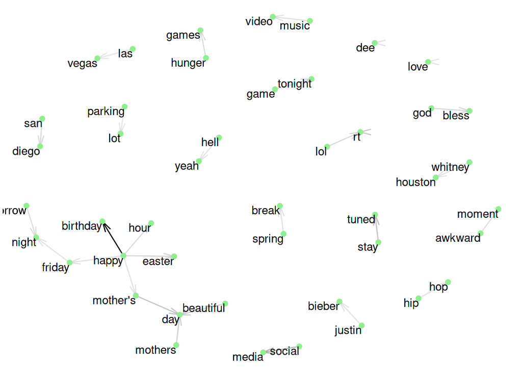

```r
library(ggraph)
a <- grid::arrow(type="open", angle=15, length=unit(.15, "inches"))
ggraph(graph_bigrams, layout="fr") +
    geom_edge_link(aes(edge_alpha=n), show.legend=FALSE, arrow=a) +
    geom_node_point(color="lightgreen", size=2) +
    geom_node_text(aes(label=name), vjust=1, hjust=1) +
    theme_void()
```

## quanteda package

Source : [get started with quanteda](https://cran.r-project.org/web/packages/quanteda/vignettes/quickstart.html) Another package to create and work with corpus.

## Terms associations

### Explore associations

```r
findFreqTerms(tdm, lowfreq=10)
```

```
  [1] "almost"   "alreadi"  "also"     "alway"    "amaz"     "anoth"
  [7] "anyon"    "around"   "ask"      "ass"      "away"     "awesom"
 [13] "babi"     "back"     "bad"      "beauti"   "best"     "better"
 [19] "big"      "birthday" "book"     "boy"      "break"    "build"
 [25] "buy"      "call"     "can"      "cant"     "car"      "care"
 [31] "caus"     "chang"    "check"    "citi"     "class"    "come"
 [37] "congrat"  "cool"     "crazi"    "day"      "dear"     "definit"
 [43] "didnt"    "die"      "doesnt"   "dog"      "done"     "dont"
 [49] "dream"    "drink"    "eat"      "els"      "email"    "end"
 [55] "enjoy"    "enough"   "even"     "event"    "ever"     "everi"
 [61] "everyon"  "everyth"  "excit"    "famili"   "favorit"  "feel"
 [67] "film"     "final"    "find"     "first"    "follow"   "forward"
 [73] "free"     "friday"   "friend"   "fuck"     "fun"      "game"
 [79] "get"      "girl"     "give"     "glad"     "god"      "gonna"
 [85] "good"     "got"      "gotta"    "great"    "guess"    "guy"
```

[output cut: 20 more lines]

```r
findAssocs(tdm, terms="people", corlimit=0.6)
```

```
$people
numeric(0)
```

by Bruno Berrehuel